# When a neuron changes its response: my investigation

## Your report starts here

Today you choose the question and defend the analysis. Reuse code from yesterday; writing functions from memory is not the goal. Each student submits **one integrated HTML notebook** with code, output, captions and their own reasoning. Save this as `04_my_investigation.Rmd`. Add useful material from your earlier notebooks where it helps explain your decisions.

Work in pairs and swap roles, but write your own interpretation. No prior statistical vocabulary is assumed: use yesterday’s notebook and ask for explanations whenever a term is unclear.

## 1. Choose a question before looking for a result — 20 minutes

| Question | Keep fixed | Compare |
| --- | --- | --- |
| Does the voltage shift persist after learning? | conditioning = Paired | Baseline vs Plateau |
| Do conditioning protocols differ during acquisition? | phase = Acquisition | Unpaired vs Paired |
| Does resting membrane potential change during acquisition? | conditioning = Paired | Baseline vs Acquisition |

**Plateau option:** the source workbook contains 10 plateau cells, while the paper caption reports 9. We retain the recorded workbook values; treat that extension as exploratory pending clarification. The first-day baseline/acquisition comparison is unaffected.

`Paired` means the cue precedes reward; `Unpaired` means those events are separated. These labels describe conditioning protocols, **not paired statistical observations**. The animals in each comparison are different rats. Each row contains mean reversal and resting potentials in millivolts (mV), plus `n_cells`, the number of cells averaged. An average based on three cells is still one animal. Day 7 labels the acquisition group; the paper describes this phase as days 5–7, so do not assume every recording was on day 7.

Choose one primary group comparison and one association. These are exploratory teaching analyses of a published dataset, not a new confirmatory study. Do not try every option and present only the smallest p-value.

## 2. Inspect and select — 30 minutes

```r
full <- read.csv("data/investigation.csv")
head(full)
```

```
##   sample_id conditioning    phase day_label reversal_mV resting_mV n_cells
## 1    Rat_01       Paired Baseline         1   -73.85000  -60.15000       1
## 2    Rat_02       Paired Baseline         1   -84.48682  -56.83034       2
## 3    Rat_03       Paired Baseline         1   -76.01080  -70.75610       1
## 4    Rat_04       Paired Baseline         1   -75.73190  -59.34840       1
## 5    Rat_05       Paired Baseline         1   -78.74960  -45.29000       2
## 6    Rat_06       Paired Baseline         1   -74.72376  -51.49626       1
```

```r
dim(full)
```

```
## [1] 26  7
```

```r
anyDuplicated(full$sample_id)
```

```
## [1] 0
```

The selection scaffold below introduces `subset()` and `&` (both conditions must hold). It keeps the experimental design explicit. `if` chooses the block matching your question. You only need to change `question_choice`; explain which rows it retains before running it.

```r
question_choice <- 0 # Change to 1, 2 or 3 after writing your question.
outcome_name <- "reversal_mV"
if (question_choice == 1) {
  selected <- subset(full, conditioning == "Paired" & phase != "Acquisition")
  selected$group <- selected$phase
  group_a <- "Baseline"; group_b <- "Plateau"
} else if (question_choice == 2) {
  selected <- subset(full, phase == "Acquisition")
  selected$group <- selected$conditioning
  group_a <- "Unpaired"; group_b <- "Paired"
} else if (question_choice == 3) {
  selected <- subset(full, conditioning == "Paired" & phase != "Plateau")
  selected$group <- selected$phase
  group_a <- "Baseline"; group_b <- "Acquisition"
  outcome_name <- "resting_mV"
} else {
  selected <- NULL
  cat("Choose one question above before continuing.")
}
```

```
## Choose one question above before continuing.
```

```r
unit <- if(outcome_name == "reversal_mV") "Mean GABA reversal potential (mV)" else "Mean resting membrane potential (mV)"
```

`selected[[outcome_name]]` retrieves the column whose name is stored as text. We use it here so the same worked code can support your chosen question. The earlier `$` notation is equally useful when you type a column name directly.

```r
if (!is.null(selected)) {
  selected$value <- selected[[outcome_name]]
  table(selected$group)
  table(is.na(selected$value))
  complete <- selected[!is.na(selected$value), ]
  complete$group <- factor(complete$group, levels=c(group_a,group_b))
  table(complete$group)
  voltage_by_group <- split(complete$value, complete$group)
  voltage_by_group # Each vector is labelled with its biological group.
}
```

`split()` keeps a separate measurement vector for each named group in `voltage_by_group`. For example, `voltage_by_group[[group_a]]` retrieves the group whose name is stored in `group_a`. Displaying the collection shows the actual group names and measurements, so these labels stay correct when you choose a different biological question.

Here `is.na()` marks missing values, `!` reverses those marks, and the bracket selection keeps the observed values. You met missingness yesterday; this supplied pattern now automates the counting and selection. It never replaces a missing value with zero.

## 3. Give the reader a picture — 35 minutes

```r
if (!is.null(selected)) {
  boxplot(value ~ group, data=complete, outline=FALSE,ylab=unit)
  set.seed(7)
  stripchart(value ~ group,data=complete,vertical=TRUE,method="jitter",add=TRUE,pch=19)
  par(mfrow=c(1,2))
  qqnorm(voltage_by_group[[group_a]],main=group_a); qqline(voltage_by_group[[group_a]])
  qqnorm(voltage_by_group[[group_b]],main=group_b); qqline(voltage_by_group[[group_b]])
  par(mfrow=c(1,1))
  mean(voltage_by_group[[group_a]]); mean(voltage_by_group[[group_b]])
  median(voltage_by_group[[group_a]]); median(voltage_by_group[[group_b]])
  sd(voltage_by_group[[group_a]]); sd(voltage_by_group[[group_b]])
  shapiro.test(voltage_by_group[[group_a]]); shapiro.test(voltage_by_group[[group_b]])
}
```

**15-minute break.**

## 4. Choose, run and interpret — 40 minutes

Write your primary method and reason **before** changing `method_choice` below. Welch compares means; Wilcoxon uses ranks and is not generally a median test. Both need independent animals. With very small samples neither is a magic fix for limited information.

```r
method_choice <- "choose" # Change to "welch" or "wilcoxon".
if (!is.null(selected)) {
  mean_difference <- mean(voltage_by_group[[group_b]]) - mean(voltage_by_group[[group_a]])
  mean_difference # group_b minus group_a
  if (method_choice == "welch") {
    group_result <- t.test(voltage_by_group[[group_b]],voltage_by_group[[group_a]])
    print(group_result)
  } else if (method_choice == "wilcoxon") {
    group_result <- wilcox.test(voltage_by_group[[group_b]],voltage_by_group[[group_a]],exact=FALSE)
    print(group_result)
  } else cat("Choose and justify your method above.
")
}
```

## 5. Investigate one association — 35 minutes

For your association, use the same selected subset and choose **one** group. Investigate its animal-mean GABA reversal potential versus resting membrane potential. Some choices have very few rats. A wide uncertainty or an unstable correlation is a finding to explain; do not quietly increase the sample size by counting cells as independent rats.

```r
association_group <- "choose" # Use exactly one of your selected group labels.
correlation_method <- "choose" # "pearson" or "spearman", chosen after inspecting the plot.
if (!is.null(selected) && association_group %in% selected$group) {
  association <- selected[selected$group == association_group, ]
  x <- association$reversal_mV
  y <- association$resting_mV
  keep <- complete.cases(x,y) # Keep animals with both measurements.
  x <- x[keep]; y <- y[keep]
  length(x)
  plot(x,y,pch=19,xlab="Mean GABA reversal potential (mV)",ylab="Mean resting membrane potential (mV)")
  if (correlation_method == "pearson") print(cor.test(x,y,method="pearson"))
  if (correlation_method == "spearman") print(cor.test(x,y,method="spearman",exact=FALSE))
} else cat("Choose one group before running the association.
")
```

```
## Choose one group before running the association.
```

**10-minute break.**

## 6. The tempting hunt for a small p-value — 20 minutes

Imagine ten unrelated comparisons when all ten null hypotheses are true. Each test conducted at a 0.05 threshold has a 5% false-positive rate under its assumptions. Trying many tests raises the chance of at least one false alarm. For independent tests it is `1 - 0.95^10`; real protein measurements can be correlated, so that exact calculation need not apply to them.

These are **invented p-values**, not results from our animals:

```r
demo_p <- c(0.01,0.03,0.20,0.80,0.04)
adjusted_p <- p.adjust(demo_p,method="bonferroni")
data.frame(raw_p=demo_p,bonferroni_p=adjusted_p)
```

```
##   raw_p bonferroni_p
## 1  0.01         0.05
## 2  0.03         0.15
## 3  0.20         1.00
## 4  0.80         1.00
## 5  0.04         0.20
```

Bonferroni multiplies each p-value by the number of tests in the chosen family, capped at 1. It controls the chance of any false rejection in that family under valid individual tests, even when tests are dependent, though it can be conservative. Define the family from the questions actually investigated, including unsuccessful attempts; not only the reported hits. At a declared threshold of adjusted p <= 0.05, which example remains? What is lost by treating 0.049 and 0.051 as completely different scientific conclusions?

## 7. Peer review and a reproducible hand-in — 35 minutes

Give your partner three minutes to read your best figure and result. They ask:

1. Which animals contributed, and why are they independent?
2. Does the method answer the stated question?
3. Is the conclusion proportionate to the estimate, uncertainty and sample size?

Write a short final conclusion: answer your question, identify your strongest evidence, state the most important limitation, and propose one useful next experiment.

```
## DRAFT: complete the question, test and association choices before submission.
```

- The HTML includes my own question, data description, figures and captions.
- It reports a group comparison and a correlation with interpretation and limitations.
- I explained exclusions and analysis-specific sample sizes.
- I identified the questions explored and explained multiple testing.
- I restarted R, ran from the first chunk, knitted and checked the resulting HTML.
- All “write here” placeholders are replaced, and the draft notice is resolved.

Submit this integrated **HTML** to the learning system; keep the `.Rmd` as your editable recipe.

## Extra: the two-cluster protein puzzle

NKCC1 helps transport chloride into cells. A Western blot measures an antibody-associated band intensity; division by GAPDH is a loading normalisation, not a measurement of absolute protein concentration. These data come from the same study, but a separate experiment.

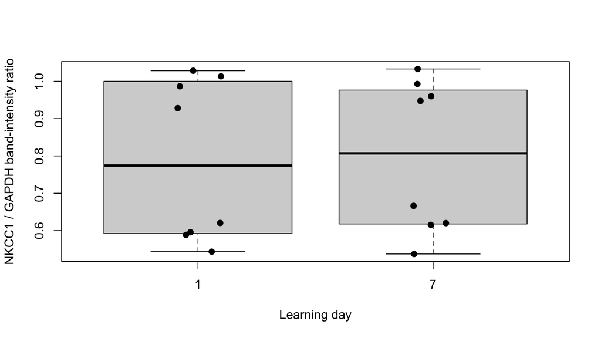

```r
protein <- read.csv("data/nkcc1.csv")
boxplot(NKCC1_GAPDH ~ factor(day), data=protein, outline=FALSE,
        xlab="Learning day", ylab="NKCC1 / GAPDH band-intensity ratio")
set.seed(7)
stripchart(NKCC1_GAPDH ~ factor(day), data=protein, vertical=TRUE,
           method="jitter",add=TRUE,pch=19)
```

Describe the gap among values before running the next chunk. Propose a biological explanation and a technical explanation. Now reveal the assay batch:

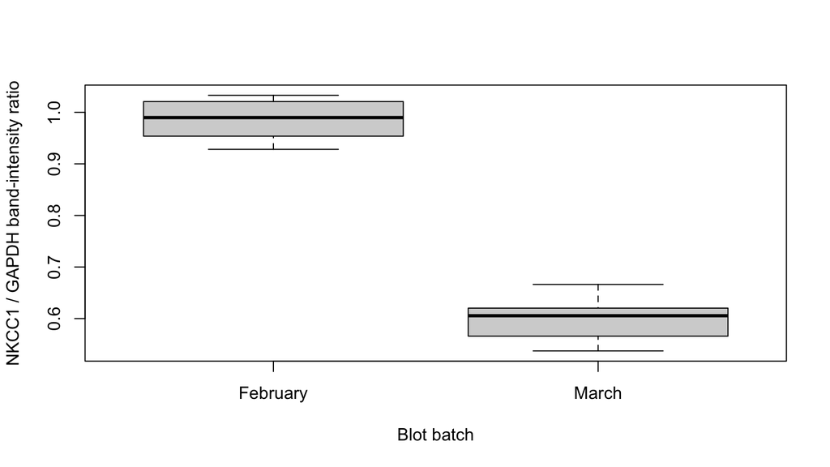

```r
boxplot(NKCC1_GAPDH ~ blot_batch, data=protein,
        xlab="Blot batch", ylab="NKCC1 / GAPDH band-intensity ratio")
```

```r
table(protein$day,protein$blot_batch)
```

```
##
##     February March
##   1        4     4
##   7        4     4
```

There are four day-1 and four day-7 animals per batch, with 16 distinct animal IDs overall. The two assay batches have different signal scales. Group balance does not make the batch effect disappear. **Use this as a descriptive design challenge:** we have not established the source’s matching scheme, so do not invent matched pairs from spreadsheet row alignment or report a simple pooled test as the definitive biological result. Propose a future experiment that balances learning day across blots, records matching and includes common reference samples. What extra information would you request before choosing a batch-aware analysis?

## Data source

https://datadryad.org/dataset/doi:10.5061/dryad.44j0zpcv7. See `data/dictionary.html` for preparation rules and the original study.